# Homework 05

Author

wenhao7

This report uses Python throughout and equal neighbor weights for every KNN fit. Predictor matrices contain only the covariates used in distance calculations and never include an intercept column.

```python
import numpy as np
import pandas as pd
import matplotlib.pyplot as plt

from IPython.display import display
from pathlib import Path
from sklearn.linear_model import Lasso
from sklearn.model_selection import KFold
from sklearn.neighbors import KNeighborsRegressor

pd.set_option("display.precision", 6)
FIGURE_DIR = Path("figures")
FIGURE_DIR.mkdir(exist_ok=True)
```

## Question 1: Estimate the bias and variance of KNN

The simulation seed is **432501**. The regression function is

$$f(\mathbf x)=0.5x_1+\sin(x_2)-0.3x_3^2,$$

with independent standard-normal predictors and independent $N(0,0.1^2)$ noise. I use $n=400$, $\mathbf{x}_0=(0.5,0.7,1)^{\mathsf T}$, Euclidean distance, and $k=1,3,\ldots,29$.

```python
Q1_SEED = 432501
rng1 = np.random.default_rng(Q1_SEED)
k_q1 = np.arange(1, 30, 2)
x0 = np.array([0.5, 0.7, 1.0])

def regression_mean(x):
    x = np.asarray(x)
    return 0.5 * x[..., 0] + np.sin(x[..., 1]) - 0.3 * x[..., 2] ** 2

f0 = float(regression_mean(x0))
print(f"f(x0) = {f0:.9f}")
```

```
f(x0) = 0.594217687
```

### a. One training dataset

Direct substitution gives

$$f(\mathbf{x}_0)=0.5(0.5)+\sin(0.7)-0.3(1)^2=0.594217687.$$

The same generated dataset is used for every $k$ below.

```python
X_q1_one = rng1.normal(size=(400, 3))
y_q1_one = regression_mean(X_q1_one) + rng1.normal(scale=0.1, size=400)
d_q1_one = np.sqrt(np.sum((X_q1_one - x0) ** 2, axis=1))
order_q1_one = np.argsort(d_q1_one, kind="stable")
cum_y_q1_one = np.cumsum(y_q1_one[order_q1_one])
pred_q1_one = np.array([cum_y_q1_one[k - 1] / k for k in k_q1])

q1_one_table = pd.DataFrame({"k": k_q1, "KNN prediction": pred_q1_one})
display(q1_one_table.style.format({"KNN prediction": "{:.6f}"}).hide(axis="index"))
```

| k | KNN prediction |
| --- | --- |
| 1 | 0.610398 |
| 3 | 0.470633 |
| 5 | 0.489371 |
| 7 | 0.400577 |
| 9 | 0.331380 |
| 11 | 0.351764 |
| 13 | 0.286469 |
| 15 | 0.300850 |
| 17 | 0.291514 |
| 19 | 0.372862 |
| 21 | 0.373209 |
| 23 | 0.410189 |
| 25 | 0.440229 |
| 27 | 0.464249 |
| 29 | 0.455640 |

### b. Repeated-simulation bias, variance, and MSE

I independently generate predictors and responses 200 times. Within a repetition, all 15 values of $k$ use that repetition’s one training dataset, producing a $200\times15$ prediction matrix.

```python
n_rep_q1 = 200
pred_matrix_q1 = np.empty((n_rep_q1, len(k_q1)))

for r in range(n_rep_q1):
    X = rng1.normal(size=(400, 3))
    y = regression_mean(X) + rng1.normal(scale=0.1, size=400)
    distances = np.sqrt(np.sum((X - x0) ** 2, axis=1))
    neighbor_order = np.argsort(distances, kind="stable")
    cumulative_neighbor_y = np.cumsum(y[neighbor_order])
    pred_matrix_q1[r, :] = [cumulative_neighbor_y[k - 1] / k for k in k_q1]

mean_prediction_q1 = pred_matrix_q1.mean(axis=0)
bias_q1 = mean_prediction_q1 - f0
squared_bias_q1 = bias_q1 ** 2
# np.mean uses divisor 200 here, as required.
variance_q1 = np.mean((pred_matrix_q1 - mean_prediction_q1) ** 2, axis=0)
mse_q1 = np.mean((pred_matrix_q1 - f0) ** 2, axis=0)
identity_difference_q1 = mse_q1 - (squared_bias_q1 + variance_q1)

q1_summary = pd.DataFrame(
    {
        "k": k_q1,
        "bias": bias_q1,
        "squared bias": squared_bias_q1,
        "variance (divisor 200)": variance_q1,
        "MSE": mse_q1,
        "MSE - (bias^2 + variance)": identity_difference_q1,
    }
)
display(
    q1_summary.style.format(
        {
            "bias": "{:.6f}",
            "squared bias": "{:.6f}",
            "variance (divisor 200)": "{:.6f}",
            "MSE": "{:.6f}",
            "MSE - (bias^2 + variance)": "{:.2e}",
        }
    ).hide(axis="index")
)
print(
    "Maximum absolute identity discrepancy:",
    f"{np.max(np.abs(identity_difference_q1)):.3e}",
)
```

| k | bias | squared bias | variance (divisor 200) | MSE | MSE - (bias^2 + variance) |
| --- | --- | --- | --- | --- | --- |
| 1 | -0.018866 | 0.000356 | 0.039964 | 0.040320 | -6.94e-18 |
| 3 | -0.026932 | 0.000725 | 0.019481 | 0.020206 | 1.73e-17 |
| 5 | -0.041420 | 0.001716 | 0.015346 | 0.017061 | -4.16e-17 |
| 7 | -0.046383 | 0.002151 | 0.011079 | 0.013230 | 8.67e-18 |
| 9 | -0.056447 | 0.003186 | 0.009890 | 0.013077 | 5.20e-18 |
| 11 | -0.065699 | 0.004316 | 0.009674 | 0.013991 | 3.64e-17 |
| 13 | -0.076900 | 0.005914 | 0.009961 | 0.015875 | 2.08e-17 |
| 15 | -0.085031 | 0.007230 | 0.009480 | 0.016710 | -5.55e-17 |
| 17 | -0.093371 | 0.008718 | 0.008688 | 0.017406 | 2.78e-17 |
| 19 | -0.100861 | 0.010173 | 0.008701 | 0.018874 | -5.20e-17 |
| 21 | -0.106396 | 0.011320 | 0.008578 | 0.019898 | 3.12e-17 |
| 23 | -0.110320 | 0.012170 | 0.008894 | 0.021065 | 8.33e-17 |
| 25 | -0.116305 | 0.013527 | 0.008550 | 0.022077 | -1.04e-17 |
| 27 | -0.120740 | 0.014578 | 0.007942 | 0.022520 | 6.59e-17 |
| 29 | -0.125404 | 0.015726 | 0.007485 | 0.023212 | -9.71e-17 |

```
Maximum absolute identity discrepancy: 9.714e-17
```

The MSE is for estimating the mean response $f(\mathbf{x}_0)$, so I do not add the irreducible response-noise variance $0.1^2$.

### Original figure

This is the correct basic figure made before applying the plot-formatting skill in Question 5.

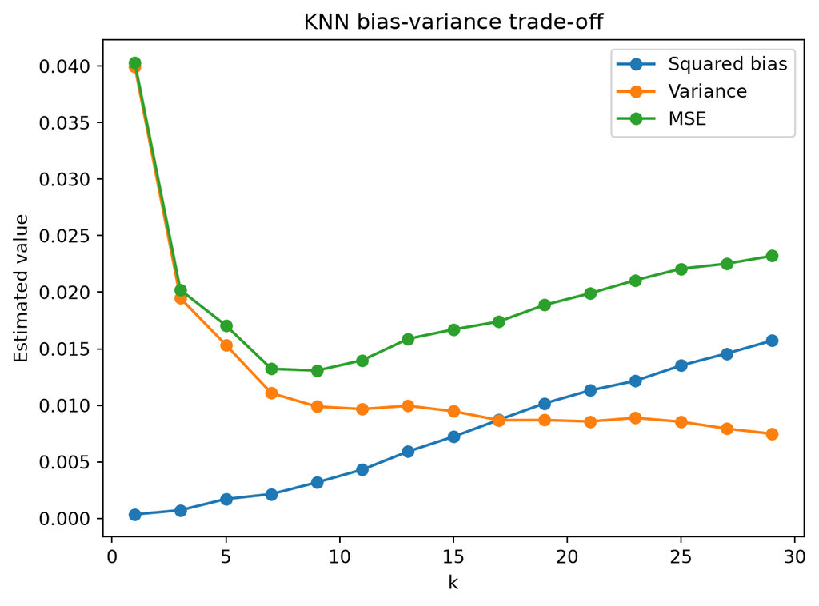

Figure 1: Original Question 1 plot before applying the custom skill.

```python
fig, ax = plt.subplots()
ax.plot(k_q1, squared_bias_q1, marker="o", label="Squared bias")
ax.plot(k_q1, variance_q1, marker="o", label="Variance")
ax.plot(k_q1, mse_q1, marker="o", label="MSE")
ax.set_title("KNN bias-variance trade-off")
ax.set_xlabel("k")
ax.set_ylabel("Estimated value")
ax.legend()
fig.savefig(FIGURE_DIR / "q1-original.png", dpi=180, bbox_inches="tight")
plt.show()
```

As $k$ increases, each prediction averages more neighbors. The variance generally decreases because the prediction depends less on individual training observations. At the same time, the estimate becomes less local, so the squared bias generally increases. The estimated MSE reflects this trade-off and is smallest at $k=9$ among the values considered in this simulation. The curves are not perfectly smooth because they are estimated from a finite number of simulations, and $k=9$ should not be treated as a universal best choice.

This is similar to ridge and lasso because stronger smoothing or regularization usually lowers variance but increases bias. In KNN the amount of smoothing is controlled by $k$, while in ridge and lasso it is controlled by the penalty parameter.

## Question 2: Compare KNN with lasso

The simulation seed is **432502**. Each setting uses 400 training and 1,000 test observations. KNN and lasso use exactly the same data within a setting.

The KNN fit is equal-weight 5NN with Euclidean distance on all 30 supplied covariates. The lasso contains only the 30 original linear covariates. Its objective is

$$\frac{1}{2n}\lVert\widetilde{\mathbf y}-\mathbf X\boldsymbol\beta\rVert_2^2
+\lambda\lVert\boldsymbol\beta\rVert_1.$$

For every cross-validation fold, the predictor means, population-form scales (divisor equal to the fold-training size), and response mean are fitted only on that fold’s training portion. I use 10 folds and 41 logarithmically spaced penalties from $10^{-4}$ through $1$.

```python
Q2_SEED = 432502
rng2 = np.random.default_rng(Q2_SEED)
lambda_grid = np.logspace(-4, 0, 41)

def generate_q2_data(rng, correlated):
    if correlated:
        sigma = np.full((30, 30), 0.8)
        np.fill_diagonal(sigma, 1.0)
        X_train = rng.multivariate_normal(np.zeros(30), sigma, size=400)
        X_test = rng.multivariate_normal(np.zeros(30), sigma, size=1000)
    else:
        X_train = rng.normal(size=(400, 30))
        X_test = rng.normal(size=(1000, 30))
    y_train = regression_mean(X_train[:, :3]) + rng.normal(scale=0.1, size=400)
    y_test = regression_mean(X_test[:, :3]) + rng.normal(scale=0.1, size=1000)
    return X_train, y_train, X_test, y_test

def fit_lasso_with_fold_preprocessing(X_train, y_train, X_test, rng_seed):
    fold_splitter = KFold(n_splits=10, shuffle=True, random_state=rng_seed)
    cv_squared_errors = np.empty((len(y_train), len(lambda_grid)))

    for train_idx, valid_idx in fold_splitter.split(X_train):
        X_fold_train = X_train[train_idx]
        y_fold_train = y_train[train_idx]
        X_fold_valid = X_train[valid_idx]
        y_fold_valid = y_train[valid_idx]

        x_mean = X_fold_train.mean(axis=0)
        x_scale = X_fold_train.std(axis=0, ddof=0)
        y_mean = y_fold_train.mean()
        X_fold_train_std = (X_fold_train - x_mean) / x_scale
        X_fold_valid_std = (X_fold_valid - x_mean) / x_scale
        y_fold_train_centered = y_fold_train - y_mean

        for j, lam in enumerate(lambda_grid):
            model = Lasso(
                alpha=lam,
                fit_intercept=False,
                max_iter=50000,
                tol=1e-9,
                selection="cyclic",
            )
            model.fit(X_fold_train_std, y_fold_train_centered)
            valid_prediction = y_mean + X_fold_valid_std @ model.coef_
            cv_squared_errors[valid_idx, j] = (y_fold_valid - valid_prediction) ** 2

    cv_mse = cv_squared_errors.mean(axis=0)
    selected_index = int(np.argmin(cv_mse))
    selected_lambda = float(lambda_grid[selected_index])

    x_mean = X_train.mean(axis=0)
    x_scale = X_train.std(axis=0, ddof=0)
    y_mean = y_train.mean()
    X_train_std = (X_train - x_mean) / x_scale
    X_test_std = (X_test - x_mean) / x_scale

    final_model = Lasso(
        alpha=selected_lambda,
        fit_intercept=False,
        max_iter=50000,
        tol=1e-9,
        selection="cyclic",
    )
    final_model.fit(X_train_std, y_train - y_mean)
    test_prediction = y_mean + X_test_std @ final_model.coef_
    # Treat tiny numerical coefficients as zero; the exact nonzero count agrees here.
    nonzero_slopes = int(np.count_nonzero(np.abs(final_model.coef_) > 1e-8))
    assert nonzero_slopes == int(np.count_nonzero(final_model.coef_))
    return test_prediction, selected_lambda, nonzero_slopes, cv_mse
```

### a. Test results

*Fit 5NN and lasso in both predictor settings and compare their test results.*

```python
q2_rows = []
q2_details = {}

for setting_number, correlated in [(1, False), (2, True)]:
    X_train, y_train, X_test, y_test = generate_q2_data(rng2, correlated)

    knn = KNeighborsRegressor(
        n_neighbors=5, weights="uniform", metric="euclidean", algorithm="brute"
    )
    knn.fit(X_train, y_train)
    knn_prediction = knn.predict(X_test)

    lasso_prediction, selected_lambda, nonzero_slopes, cv_mse = (
        fit_lasso_with_fold_preprocessing(
            X_train, y_train, X_test, rng_seed=Q2_SEED + setting_number
        )
    )

    knn_mse = float(np.mean((y_test - knn_prediction) ** 2))
    lasso_mse = float(np.mean((y_test - lasso_prediction) ** 2))
    q2_rows.append(
        {
            "setting": setting_number,
            "predictor structure": "independent" if not correlated else "off-diagonal correlation 0.8",
            "5NN test MSE": knn_mse,
            "lasso test MSE": lasso_mse,
            "selected lambda": selected_lambda,
            "nonzero lasso slopes": nonzero_slopes,
        }
    )
    q2_details[setting_number] = {
        "y_test": y_test,
        "knn_prediction": knn_prediction,
        "lasso_prediction": lasso_prediction,
        "cv_mse": cv_mse,
    }

q2_results = pd.DataFrame(q2_rows)
display(
    q2_results.style.format(
        {
            "5NN test MSE": "{:.6f}",
            "lasso test MSE": "{:.6f}",
            "selected lambda": "{:.6g}",
        }
    ).hide(axis="index")
)
```

| setting | predictor structure | 5NN test MSE | lasso test MSE | selected lambda | nonzero lasso slopes |
| --- | --- | --- | --- | --- | --- |
| 1 | independent | 0.496471 | 0.232285 | 0.0316228 | 6 |
| 2 | off-diagonal correlation 0.8 | 0.167239 | 0.247109 | 0.0158489 | 6 |

### b. Comparison between the two settings

*Compare the predictor settings and explain how correlation changes KNN neighborhoods.*

In the independent-predictor setting, lasso had the smaller test MSE in this simulation. In the correlated-predictor setting, 5NN had the smaller test MSE.

With independent predictors, many variables that are not directly related to the response still contribute to the Euclidean distance. This can make it harder for KNN to find useful neighbors. When the predictors are strongly correlated, several variables move together and may partly reflect information in the relevant predictors, so the nearest-neighbor structure can be more useful.

Lasso uses the predictors differently from KNN. KNN includes every supplied predictor in the distance calculation, while lasso can shrink some coefficients to zero. Here lasso kept 6 nonzero slopes in both settings.

### c. Nonlinearity and interpretation

*Explain how the nonlinear true model affects the KNN-lasso comparison.*

The true response contains $\sin(X_2)$ and $X_3^2$, but the lasso model uses only the original predictors as linear terms. Therefore, the fitted lasso model cannot represent the true response function exactly.

Because lasso is restricted to linear terms, the difference in test MSE reflects not only how the methods use correlation, but also the fact that lasso cannot represent the nonlinear parts of the true response exactly.

These results come from one simulated dataset for each setting. I would not conclude that correlation always helps KNN or that either method is always better.

## Question 3: Observed dimension and latent dimension

The simulation seed is **432503**. Both settings have $p=100$ observed covariates. Their latent dimensions are $m=3$ and $m=30$, and KNN receives only $\mathbf X$, never $\mathbf Z$ or $\mathbf A$. The neighbor values are $k=2,10,18,\ldots,82$.

For each generated dataset, one matrix $\mathbf A$ is shared by all of its training and test observations:

$$\mathbf X_i=\mathbf A\mathbf Z_i+\boldsymbol\eta_i,
\qquad
Y_i=Z_{i1}+Z_{i2}+\epsilon_i,$$

All entries of $\mathbf A$ are Uniform$[-2,2]$, and all entries of $\mathbf Z$, $\boldsymbol\eta$, and $\epsilon$ are mutually independent standard normals.

```python
Q3_SEED = 432503
rng3 = np.random.default_rng(Q3_SEED)
k_q3 = np.arange(2, 83, 8)

def q3_dataset_mse(rng, latent_dimension):
    p = 100
    n_train = 200
    n_test = 200
    A = rng.uniform(-2, 2, size=(p, latent_dimension))

    Z_train = rng.normal(size=(n_train, latent_dimension))
    Z_test = rng.normal(size=(n_test, latent_dimension))
    X_train = Z_train @ A.T + rng.normal(size=(n_train, p))
    X_test = Z_test @ A.T + rng.normal(size=(n_test, p))
    y_train = Z_train[:, 0] + Z_train[:, 1] + rng.normal(size=n_train)
    y_test = Z_test[:, 0] + Z_test[:, 1] + rng.normal(size=n_test)

    # Squared Euclidean distance gives exactly the same neighbor ordering as
    # Euclidean distance; omitting the square root avoids needless work.
    squared_distances = (
        np.sum(X_test ** 2, axis=1)[:, None]
        + np.sum(X_train ** 2, axis=1)[None, :]
        - 2 * X_test @ X_train.T
    )
    squared_distances = np.maximum(squared_distances, 0.0)
    neighbor_order = np.argsort(squared_distances, axis=1, kind="stable")
    ordered_y = y_train[neighbor_order]
    cumulative_y = np.cumsum(ordered_y, axis=1)
    predictions = np.column_stack(
        [cumulative_y[:, k - 1] / k for k in k_q3]
    )
    mse = np.mean((predictions - y_test[:, None]) ** 2, axis=0)
    return mse
```

### a. One dataset per latent dimension

*Calculate test MSE across the specified values of $k$ for one dataset in each setting.*

```python
q3_one_m3 = q3_dataset_mse(rng3, 3)
q3_one_m30 = q3_dataset_mse(rng3, 30)
q3_one_table = pd.DataFrame(
    {"k": k_q3, "test MSE (m=3)": q3_one_m3, "test MSE (m=30)": q3_one_m30}
)
display(
    q3_one_table.style.format(
        {"test MSE (m=3)": "{:.6f}", "test MSE (m=30)": "{:.6f}"}
    ).hide(axis="index")
)
```

| k | test MSE (m=3) | test MSE (m=30) |
| --- | --- | --- |
| 2 | 1.665054 | 2.340092 |
| 10 | 1.318560 | 1.936507 |
| 18 | 1.340225 | 2.004582 |
| 26 | 1.351233 | 2.046530 |
| 34 | 1.393077 | 2.089447 |
| 42 | 1.470485 | 2.129968 |
| 50 | 1.549634 | 2.205560 |
| 58 | 1.631096 | 2.216876 |
| 66 | 1.676659 | 2.241936 |
| 74 | 1.743599 | 2.258079 |
| 82 | 1.809513 | 2.281793 |

Within each latent-dimension setting, every value of $k$ uses the same 200 training and 200 test observations.

### b. Fifty complete repetitions

*Average the test MSE over 50 independently generated datasets for each latent dimension.*

Each repetition below generates a new $\mathbf A$, new training observations, and new test observations for each value of $m$.

```python
n_rep_q3 = 50
q3_mse_repetitions = {
    3: np.empty((n_rep_q3, len(k_q3))),
    30: np.empty((n_rep_q3, len(k_q3))),
}

for r in range(n_rep_q3):
    for m in (3, 30):
        q3_mse_repetitions[m][r, :] = q3_dataset_mse(rng3, m)

q3_average_mse = {m: values.mean(axis=0) for m, values in q3_mse_repetitions.items()}
q3_average_table = pd.DataFrame(
    {
        "k": k_q3,
        "average test MSE (m=3)": q3_average_mse[3],
        "average test MSE (m=30)": q3_average_mse[30],
    }
)
display(
    q3_average_table.style.format(
        {"average test MSE (m=3)": "{:.6f}", "average test MSE (m=30)": "{:.6f}"}
    ).hide(axis="index")
)
```

| k | average test MSE (m=3) | average test MSE (m=30) |
| --- | --- | --- |
| 2 | 1.615175 | 3.046744 |
| 10 | 1.260788 | 2.331666 |
| 18 | 1.272165 | 2.324473 |
| 26 | 1.322585 | 2.350719 |
| 34 | 1.368716 | 2.373310 |
| 42 | 1.422723 | 2.400749 |
| 50 | 1.481014 | 2.431532 |
| 58 | 1.536732 | 2.459393 |
| 66 | 1.595508 | 2.486041 |
| 74 | 1.654166 | 2.515926 |
| 82 | 1.716742 | 2.541421 |

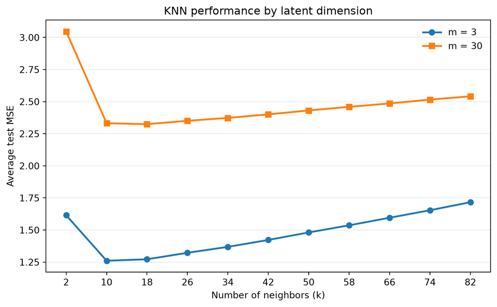

Figure 2: Average test MSE across 50 complete repetitions. These are controlled simulation curves, not cross-validation curves.

```python
fig, ax = plt.subplots(figsize=(7.5, 4.6), constrained_layout=True)
ax.plot(k_q3, q3_average_mse[3], marker="o", linewidth=2, label="m = 3")
ax.plot(k_q3, q3_average_mse[30], marker="s", linewidth=2, label="m = 30")
ax.set_title("KNN performance by latent dimension")
ax.set_xlabel("Number of neighbors (k)")
ax.set_ylabel("Average test MSE")
ax.set_xticks(k_q3)
ax.grid(axis="y", alpha=0.25)
ax.legend(frameon=False)
fig.savefig(FIGURE_DIR / "q3-average-mse.png", dpi=180, bbox_inches="tight")
plt.show()
```

### c. Interpretation

*Explain why the latent dimension and observation noise affect KNN even though both settings have 100 observed predictors.*

In my simulation, the average test MSE curve for $m=3$ is below the curve for $m=30$ across the displayed values of $k$. Both settings have 100 observed predictors, but their underlying structures are different. When $m=30$, more latent directions affect the observed Euclidean distances even though only $Z_1$ and $Z_2$ directly determine $Y$.

The noise vector $\eta$ adds variation in all 100 observed coordinates. Because of this noise, the observations do not lie exactly in an $m$-dimensional linear subspace.

These curves compare the two simulated settings; they are not being used to choose a final value of $k$.

## Question 4: Classify handwritten digits

I use the first 1,000 training rows and first 500 test rows from the official course copies. Pixel values are unstandardized, and the label column is separated before distance calculation.

$$d_E(\mathbf x_0,\mathbf x_i)
=\sqrt{\sum_{j=1}^{256}(x_{0j}-x_{ij})^2},
\qquad
d_M(\mathbf x_0,\mathbf x_i)
=\sum_{j=1}^{256}|x_{0j}-x_{ij}|.$$

### a. Manual 5NN classifier

*Implement deterministic 5NN directly for Euclidean and Manhattan distances.*

The function directly evaluates each formula. `np.lexsort` uses distance as the primary key and zero-based training row as the secondary key, so a distance tie goes to the smaller training row number. `argmax` on counts indexed 0 through 9 returns the smallest digit in a voting tie.

```python
zip_train = pd.read_csv("data/knn/zip-train.csv.gz", header=None, compression="gzip")
zip_test = pd.read_csv("data/knn/zip-test.csv.gz", header=None, compression="gzip")

y_digit_train = zip_train.iloc[:1000, 0].to_numpy(dtype=int)
X_digit_train = zip_train.iloc[:1000, 1:].to_numpy(dtype=float)
y_digit_test = zip_test.iloc[:500, 0].to_numpy(dtype=int)
X_digit_test = zip_test.iloc[:500, 1:].to_numpy(dtype=float)

assert X_digit_train.shape == (1000, 256)
assert X_digit_test.shape == (500, 256)

def manual_five_nn_predict(X_train, y_train, X_test, distance):
    predictions = np.empty(X_test.shape[0], dtype=int)
    training_rows = np.arange(X_train.shape[0])

    for test_row, x0 in enumerate(X_test):
        if distance == "euclidean":
            distances = np.sqrt(np.sum((X_train - x0) ** 2, axis=1))
        elif distance == "manhattan":
            distances = np.sum(np.abs(X_train - x0), axis=1)
        else:
            raise ValueError("distance must be 'euclidean' or 'manhattan'")

        five_nearest = np.lexsort((training_rows, distances))[:5]
        vote_counts = np.bincount(y_train[five_nearest], minlength=10)
        predictions[test_row] = int(np.argmax(vote_counts))

    return predictions
```

### b. Classification errors and confusion matrices

*Report both error rates, the two confusion matrices, and the most common directional mistakes.*

```python
pred_euclidean = manual_five_nn_predict(
    X_digit_train, y_digit_train, X_digit_test, "euclidean"
)
pred_manhattan = manual_five_nn_predict(
    X_digit_train, y_digit_train, X_digit_test, "manhattan"
)

def confusion_predicted_rows(prediction, truth):
    matrix = np.zeros((10, 10), dtype=int)
    np.add.at(matrix, (prediction, truth), 1)
    return matrix

conf_euclidean = confusion_predicted_rows(pred_euclidean, y_digit_test)
conf_manhattan = confusion_predicted_rows(pred_manhattan, y_digit_test)
error_euclidean = float(np.mean(pred_euclidean != y_digit_test))
error_manhattan = float(np.mean(pred_manhattan != y_digit_test))

q4_error_table = pd.DataFrame(
    {
        "distance": ["Euclidean", "Manhattan"],
        "errors": [int(np.sum(pred_euclidean != y_digit_test)), int(np.sum(pred_manhattan != y_digit_test))],
        "classification error": [error_euclidean, error_manhattan],
    }
)
display(q4_error_table.style.format({"classification error": "{:.4f}"}).hide(axis="index"))

print("Euclidean confusion matrix (rows = predicted, columns = true)")
display(pd.DataFrame(conf_euclidean, index=pd.Index(range(10), name="predicted"), columns=pd.Index(range(10), name="true")))
print("Manhattan confusion matrix (rows = predicted, columns = true)")
display(pd.DataFrame(conf_manhattan, index=pd.Index(range(10), name="predicted"), columns=pd.Index(range(10), name="true")))

assert conf_euclidean.sum() == 500
assert conf_manhattan.sum() == 500
assert np.trace(conf_euclidean) == np.sum(pred_euclidean == y_digit_test)
assert np.trace(conf_manhattan) == np.sum(pred_manhattan == y_digit_test)
```

| distance | errors | classification error |
| --- | --- | --- |
| Euclidean | 61 | 0.1220 |
| Manhattan | 69 | 0.1380 |

```
Euclidean confusion matrix (rows = predicted, columns = true)
```

| true predicted | 0 | 1 | 2 | 3 | 4 | 5 | 6 | 7 | 8 | 9 |
| --- | --- | --- | --- | --- | --- | --- | --- | --- | --- | --- |
| 0 | 118 | 0 | 7 | 1 | 0 | 4 | 2 | 0 | 2 | 0 |
| 1 | 0 | 66 | 0 | 0 | 2 | 0 | 0 | 0 | 0 | 1 |
| 2 | 0 | 0 | 39 | 1 | 0 | 0 | 2 | 0 | 0 | 1 |
| 3 | 0 | 0 | 0 | 23 | 0 | 4 | 0 | 0 | 2 | 0 |
| 4 | 0 | 0 | 1 | 0 | 27 | 1 | 1 | 1 | 0 | 1 |
| 5 | 0 | 0 | 0 | 1 | 0 | 13 | 0 | 0 | 0 | 0 |
| 6 | 0 | 2 | 0 | 0 | 0 | 1 | 41 | 0 | 2 | 0 |
| 7 | 0 | 0 | 0 | 0 | 1 | 1 | 0 | 34 | 0 | 4 |
| 8 | 0 | 0 | 3 | 2 | 0 | 2 | 0 | 0 | 37 | 0 |
| 9 | 1 | 0 | 0 | 1 | 4 | 0 | 0 | 1 | 1 | 41 |

```
Manhattan confusion matrix (rows = predicted, columns = true)
```

| true predicted | 0 | 1 | 2 | 3 | 4 | 5 | 6 | 7 | 8 | 9 |
| --- | --- | --- | --- | --- | --- | --- | --- | --- | --- | --- |
| 0 | 118 | 0 | 6 | 1 | 0 | 5 | 3 | 0 | 4 | 0 |
| 1 | 0 | 67 | 2 | 0 | 2 | 0 | 1 | 0 | 0 | 1 |
| 2 | 0 | 0 | 35 | 0 | 0 | 0 | 2 | 0 | 0 | 0 |
| 3 | 0 | 0 | 1 | 24 | 0 | 4 | 0 | 0 | 2 | 0 |
| 4 | 0 | 0 | 1 | 1 | 27 | 1 | 0 | 1 | 0 | 1 |
| 5 | 0 | 0 | 0 | 1 | 0 | 11 | 0 | 0 | 0 | 0 |
| 6 | 0 | 1 | 0 | 0 | 0 | 2 | 40 | 0 | 2 | 0 |
| 7 | 0 | 0 | 2 | 1 | 1 | 0 | 0 | 34 | 0 | 5 |
| 8 | 0 | 0 | 2 | 0 | 0 | 3 | 0 | 0 | 34 | 0 |
| 9 | 1 | 0 | 1 | 1 | 4 | 0 | 0 | 1 | 2 | 41 |

```python
def top_directed_confusions(matrix, n=5):
    off_diagonal = matrix.copy()
    np.fill_diagonal(off_diagonal, 0)
    locations = np.dstack(
        np.unravel_index(np.argsort(off_diagonal.ravel())[::-1], off_diagonal.shape)
    )[0]
    rows = []
    for predicted, true in locations:
        count = int(off_diagonal[predicted, true])
        if count == 0:
            break
        rows.append((int(true), int(predicted), count))
        if len(rows) == n:
            break
    return rows

top_euclidean = top_directed_confusions(conf_euclidean)
top_manhattan = top_directed_confusions(conf_manhattan)

top_confusion_table = pd.DataFrame(
    [
        {
            "distance": distance,
            "true digit": true,
            "predicted digit": predicted,
            "count": count,
        }
        for distance, rows in [
            ("Euclidean", top_euclidean),
            ("Manhattan", top_manhattan),
        ]
        for true, predicted, count in rows
    ]
)
display(top_confusion_table.style.hide(axis="index"))
```

| distance | true digit | predicted digit | count |
| --- | --- | --- | --- |
| Euclidean | 2 | 0 | 7 |
| Euclidean | 9 | 7 | 4 |
| Euclidean | 5 | 3 | 4 |
| Euclidean | 4 | 9 | 4 |
| Euclidean | 5 | 0 | 4 |
| Manhattan | 2 | 0 | 6 |
| Manhattan | 9 | 7 | 5 |
| Manhattan | 5 | 0 | 5 |
| Manhattan | 4 | 9 | 4 |
| Manhattan | 8 | 0 | 4 |

For both distance measures, the most common error was a true 2 being predicted as 0. Another common error was a true 9 being predicted as 7. Other frequent mistakes included true 5s being predicted as 0 or 3 and true 4s being predicted as 9. With Manhattan distance, true 8s were also predicted as 0 four times.

### c. Three Euclidean errors and comparison

*Inspect three Euclidean errors and compare the mistakes made by the two distance measures.*

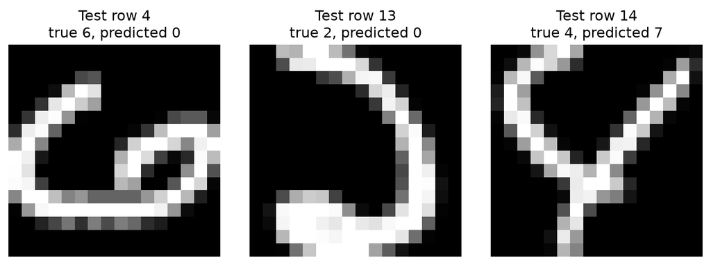

Figure 3: Three test images misclassified by Euclidean 5NN.

```python
euclidean_error_indices = np.flatnonzero(pred_euclidean != y_digit_test)
shown_error_indices = euclidean_error_indices[:3]

fig, axes = plt.subplots(1, 3, figsize=(8.5, 3.0), constrained_layout=True)
for ax, idx in zip(axes, shown_error_indices):
    ax.imshow(X_digit_test[idx].reshape(16, 16), cmap="gray", interpolation="nearest")
    ax.set_title(f"Test row {idx + 1}\ntrue {y_digit_test[idx]}, predicted {pred_euclidean[idx]}")
    ax.axis("off")
fig.savefig(FIGURE_DIR / "q4-euclidean-errors.png", dpi=200, bbox_inches="tight")
plt.show()
```

```python
euclidean_error_set = set(np.flatnonzero(pred_euclidean != y_digit_test))
manhattan_error_set = set(np.flatnonzero(pred_manhattan != y_digit_test))
common_errors = euclidean_error_set & manhattan_error_set
only_euclidean = euclidean_error_set - manhattan_error_set
only_manhattan = manhattan_error_set - euclidean_error_set

q4_overlap_table = pd.DataFrame(
    {
        "shared errors": [len(common_errors)],
        "Euclidean only": [len(only_euclidean)],
        "Manhattan only": [len(only_manhattan)],
    }
)
display(q4_overlap_table.style.hide(axis="index"))
```

| shared errors | Euclidean only | Manhattan only |
| --- | --- | --- |
| 58 | 3 | 11 |

The first error makes some sense to me because most of the 6 forms a closed shape, although I would still read it as a 6. The second one is less obvious to me. I would still read it as a 2, but its strokes look round and crowded, so I can understand why nearby training images could lead to a 0. The third error is easier to understand because the 4 has a strong diagonal shape and looks closer to a 7 than many handwritten 4s do.

Euclidean distance has error 0.1220, while Manhattan distance has error 0.1380. The two methods have fairly similar overall error rates, but they do not make exactly the same mistakes. They share 58 misclassified images; 3 errors occur only with Euclidean distance and 11 occur only with Manhattan distance. This shows that similar total error does not imply identical predictions.

## Question 5: Create a plot-formatting skill

### a. Design and installation

I created and installed the explicit-only skill `stat432-plot-formatting`. Its description limits it to STAT 432 homework plots and says it should be used only after an explicit request. The rules apply to both Python and R plots.

### b. Explicit test on the Question 1 plot

I explicitly invoked `$stat432-plot-formatting` on the original Question 1 plot. The revised version has clearer axis labels, readable text sizes, a colorblind-friendly palette, different markers and line styles, and a lighter grid. The data and axis scale are unchanged.

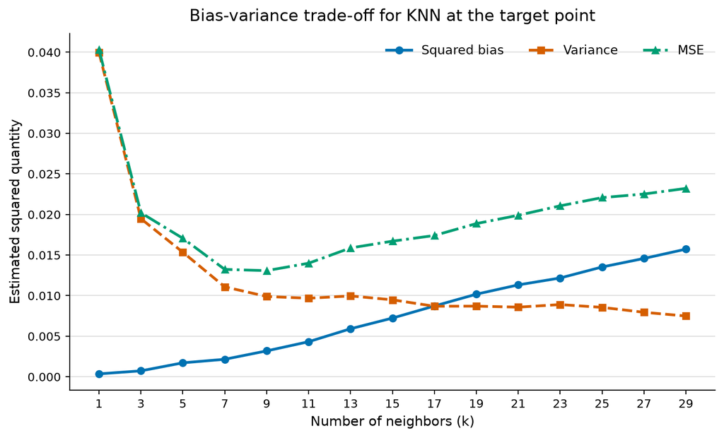

Figure 4: Revised Question 1 plot after explicitly applying the custom STAT 432 plot-formatting skill.

```python
fig, ax = plt.subplots(figsize=(8.0, 4.8), constrained_layout=True)
series = [
    (squared_bias_q1, "Squared bias", "#0072B2", "o", "-"),
    (variance_q1, "Variance", "#D55E00", "s", "--"),
    (mse_q1, "MSE", "#009E73", "^", "-."),
]
for values, label, color, marker, linestyle in series:
    ax.plot(
        k_q1,
        values,
        label=label,
        color=color,
        marker=marker,
        linestyle=linestyle,
        linewidth=2.2,
        markersize=5.5,
    )
ax.set_title("Bias-variance trade-off for KNN at the target point", fontsize=13, pad=10)
ax.set_xlabel("Number of neighbors (k)", fontsize=11)
ax.set_ylabel("Estimated squared quantity", fontsize=11)
ax.set_xticks(k_q1)
ax.tick_params(axis="both", labelsize=9.5)
ax.grid(axis="y", color="#D0D0D0", linewidth=0.8, alpha=0.7)
ax.spines[["top", "right"]].set_visible(False)
ax.legend(frameon=False, fontsize=10, ncol=3)
fig.savefig(FIGURE_DIR / "q1-revised.png", dpi=200, bbox_inches="tight")
plt.show()
```

I preferred the revised version because the labels and line styles are easier to read, and the curves can still be distinguished without relying only on color. The first skill-guided revision was clear enough, so I kept it.

### c. Final `SKILL.md`

The following is the complete installed content.

```markdown
---
name: stat432-plot-formatting
description: Improve the presentation of plots for STAT 432 homework reports. Use this skill only after an explicit request to apply it; do not invoke it automatically for unrelated plots or courses.
---

# STAT 432 Plot Formatting

Use these rules for explicitly requested improvements to STAT 432 homework plots in Python or R. Keep the data, statistical result, and scale unchanged.

- Leave enough margin so titles, labels, tick marks, and legends are not clipped.
- Keep titles short and descriptive.
- Use honest axes and clear labels, including units or transformed scales when needed.
- Choose readable font, line, and point sizes for the final HTML or PDF.
- Use a colorblind-friendly palette, with line styles or markers when series must also be distinguishable without color.
- Keep backgrounds and grid lines simple, and remove decoration that does not help interpretation.
- Check the final rendered plot for crowding, clipping, unclear colors, or misleading emphasis.
```

## AI Use

I used OpenAI Codex to help implement and check the computational workflow, create and test the required plotting skill, and verify the final render. I reviewed the code, results, and explanations used in the report.